# Hospitalisation or death analysis for BA.2 variant

Steven Kerr, Chris Robertson

2/3/2022

## Introduction

A covid admission to hospital is taken to be individuals who have a positive covid test within 14 days prior to admission or who tested positive within 2 days of admission. Also included are patients who were already in hospital and then tested positive, more than 2 days post admission. The latter group are not included in the analysis of the risk of hospital admission from the community with covid as they are already in hospital.

The varaiant variable takes one of the values: delta, B.1.1.529, BA.2 and other.

The viral sequencing data are linked to the EAVE study data of GP clincial conditions.

Hospital admission is derived from the RAPID database only. This database records admissions to hospital and for many patients there are repeat admissions within a short space of time, sometimes with missing discharge dates. The rule for combining repeat admission episodes into putative continuous inpatient stays is the same as for the hospital acquired covid infection report. Episodes where the discharge date on one is the same or the day before the admission date of the following episode are combined; if the discahrge date is missing and a subsequent admission is within 2 days of the previous one the episodes are combined; if the discharge date is missing and there is a subsequent admission 3 or more days in the future then the discahrge date is set to 2 days after admission.

Vaccination status is defined at the date the of the positive PCR test. It is coded as unvaccinated (uv), one dose and tested positive within 27 days (v1_0_27), one dose and 28+ days (v1_28+), two doses and tested positive within 27 days (v2_0_27), two doses and 28+ days (v2_28+), three doses and tested positive within 27 days (v3_0_27), three doses and 28+ days (v3_28+). In the descriptive tables, 'vs' is the vaccination status variable.

n_tests is number of positive tests before the cohort start date. n_hh_gp is the number of people in their househld. ave_hh_age is average household age. ur6_2016 is urban-rural classification. lab = lh means test was done in a lighthouse lab.

## Descriptives

### Cohort

vacc_type_comb is their latest vaccination status.

| Characteristic | Levels | Total |
| --- | --- | --- |
| Total | NA | 5,360,910 (100.0%) |
| Sex | F | 2,729,363 (50.9%) |
|  | M | 2,631,548 (49.1%) |
| ageYear | mean.sd | 41.6 (22.7) |
|  | median.iqr | 40.5 (35.8083550043212) |
| age_grp | <18 | 948,892 (17.7%) |
|  | 18-64 | 3,434,304 (64.1%) |
|  | 65-79 | 741,757 (13.8%) |
|  | 80+ | 235,958 (4.4%) |
| vacc_type_comb | AZ_v1 | 30,736 (0.6%) |
|  | AZ_v2 | 643,471 (12.0%) |
|  | AZ_v3 | 8,691 (0.2%) |
|  | PB_v1 | 163,777 (3.1%) |
|  | PB_v2 | 752,811 (14.0%) |
|  | PB_v3 | 2,268,921 (42.3%) |
|  | uv | 1,492,456 (27.8%) |
|  | NA | 47 (0.0%) |
| simd2020_sc_quintile | 1 | 1,075,272 (20.1%) |
|  | 2 | 1,053,321 (19.6%) |
|  | 3 | 1,042,264 (19.4%) |
|  | 4 | 1,070,800 (20.0%) |
|  | 5 | 1,072,677 (20.0%) |
|  | NA | 46,577 (0.9%) |
| ur6_2016_name | 1 Large Urban Areas | 1,870,236 (34.9%) |
|  | 2 Other Urban Areas | 1,940,652 (36.2%) |
|  | 3 Accessible Small Towns | 498,211 (9.3%) |
|  | 4 Remote Small Towns | 256,183 (4.8%) |
|  | 5 Accessible Rural | 485,864 (9.1%) |
|  | 6 Remote Rural | 263,187 (4.9%) |
|  | Unknown | 46,577 (0.9%) |

[output cut: 91 more lines]

### All who tested positive during cohort time period

[output not shown]

[output cut: 119 more lines]

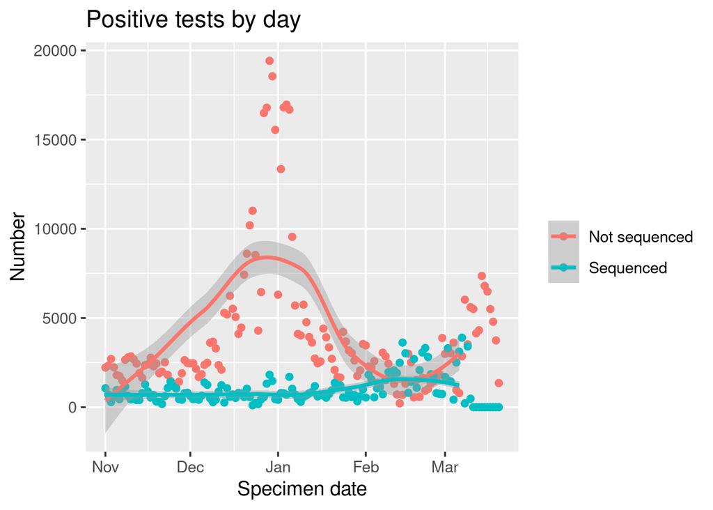

### All who have viral sequencing data

| Characteristic | Levels | B.1.1.529 | BA.2 | delta | other |
| --- | --- | --- | --- | --- | --- |
| Total N (%) | NA | 53454 (53.6) | 25891 (26.0) | 14598 (14.6) | 5756 (5.8) |
| Sex | F | 30380 (56.8) | 14629 (56.5) | 7766 (53.2) | 3148 (54.7) |
|  | M | 23074 (43.2) | 11262 (43.5) | 6832 (46.8) | 2608 (45.3) |
| ageYear | Mean (SD) | 42.3 (17.3) | 40.8 (15.2) | 44.2 (15.1) | 43.3 (14.7) |
| age_grp | 18-64 | 47445 (88.8) | 24080 (93.0) | 13272 (90.9) | 5310 (92.3) |
|  | 65-79 | 3916 (7.3) | 1473 (5.7) | 958 (6.6) | 325 (5.6) |
|  | 80+ | 2093 (3.9) | 338 (1.3) | 368 (2.5) | 121 (2.1) |
| vs | uv | 6947 (13.0) | 3411 (13.2) | 2584 (17.7) | 944 (16.4) |
|  | v1_0:27 | 127 (0.2) | 31 (0.1) | 50 (0.3) | 21 (0.4) |
|  | v1_28+ | 1591 (3.0) | 756 (2.9) | 556 (3.8) | 199 (3.5) |
|  | v2_0:27 | 137 (0.3) | 38 (0.1) | 46 (0.3) | 17 (0.3) |
|  | v2_28+ | 13149 (24.6) | 4292 (16.6) | 9359 (64.1) | 3636 (63.2) |
|  | v3_0:27 | 4485 (8.4) | 513 (2.0) | 1311 (9.0) | 585 (10.2) |
|  | v3_28+ | 27018 (50.5) | 16850 (65.1) | 692 (4.7) | 354 (6.2) |
| vs_type | AZ_v1_0:27 | 1 (0.0) | 1 (0.0) | 1 (0.0) | 1 (0.0) |
|  | AZ_v1_28+ | 381 (0.7) | 150 (0.6) | 180 (1.2) | 52 (0.9) |
|  | AZ_v2_0:27 | 29 (0.1) | 4 (0.0) | 16 (0.1) | 4 (0.1) |
|  | AZ_v2_28+ | 4118 (7.7) | 1216 (4.7) | 5864 (40.2) | 2229 (38.7) |
|  | AZ_v3_0:27 | 9 (0.0) | 3 (0.0) | 6 (0.0) | 3 (0.1) |
|  | AZ_v3_28+ | 111 (0.2) | 51 (0.2) | 6 (0.0) | 3 (0.1) |
|  | Mo_v1_0:27 | 42 (0.1) | 13 (0.1) | 8 (0.1) | 4 (0.1) |
|  | Mo_v1_28+ | 218 (0.4) | 132 (0.5) | 59 (0.4) | 23 (0.4) |
|  | Mo_v2_0:27 | 23 (0.0) | 8 (0.0) | 7 (0.0) | 2 (0.0) |
|  | Mo_v2_28+ | 1429 (2.7) | 545 (2.1) | 261 (1.8) | 121 (2.1) |
|  | Mo_v3_0:27 | 1462 (2.7) | 219 (0.8) | 258 (1.8) | 132 (2.3) |
|  | Mo_v3_28+ | 5939 (11.1) | 4762 (18.4) | 64 (0.4) | 37 (0.6) |
|  | PB_v1_0:27 | 84 (0.2) | 17 (0.1) | 41 (0.3) | 16 (0.3) |
|  | PB_v1_28+ | 992 (1.9) | 474 (1.8) | 317 (2.2) | 124 (2.2) |
|  | PB_v2_0:27 | 85 (0.2) | 26 (0.1) | 23 (0.2) | 11 (0.2) |
|  | PB_v2_28+ | 7602 (14.2) | 2531 (9.8) | 3234 (22.2) | 1286 (22.3) |

[output cut: 117 more lines]

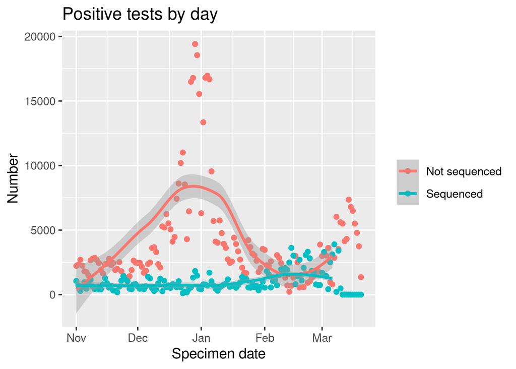

### All who were sequenced, stratified by whether they were in hospital at specimen date

| Characteristic | Levels | Not in hospital | In hospital |
| --- | --- | --- | --- |
| Total N (%) |  | 98133 (98.4) | 1566 (1.6) |
| Sex | F | 55113 (56.2) | 810 (51.7) |
|  | M | 43020 (43.8) | 756 (48.3) |
| ageYear | Mean (SD) | 41.8 (15.9) | 70.4 (17.5) |
| age_grp | 18-64 | 89644 (91.3) | 463 (29.6) |
|  | 65-79 | 6158 (6.3) | 514 (32.8) |
|  | 80+ | 2331 (2.4) | 589 (37.6) |
| vs | uv | 13730 (14.0) | 156 (10.0) |
|  | v1_0:27 | 224 (0.2) | 5 (0.3) |
|  | v1_28+ | 3063 (3.1) | 39 (2.5) |
|  | v2_0:27 | 232 (0.2) | 6 (0.4) |
|  | v2_28+ | 30008 (30.6) | 428 (27.3) |
|  | v3_0:27 | 6802 (6.9) | 92 (5.9) |
|  | v3_28+ | 44074 (44.9) | 840 (53.6) |
| lab | lh | 81477 (91.0) | 141 (10.8) |
|  | nhs | 8021 (9.0) | 1167 (89.2) |
| hosp_covid | 0 | 95379 (97.2) | 0 (0.0) |
|  | 1 | 2754 (2.8) | 1566 (100.0) |
| hosp_covid_emerg | 0 | 95639 (97.5) | 198 (12.6) |
|  | 1 | 2494 (2.5) | 1368 (87.4) |
| death_covid | 0 | 97774 (99.6) | 1409 (90.0) |
|  | 1 | 359 (0.4) | 157 (10.0) |
| death | 0 | 97738 (99.6) | 1388 (88.6) |
|  | 1 | 395 (0.4) | 178 (11.4) |
| simd2020_sc_quintile | 1 | 21278 (21.8) | 451 (28.9) |
|  | 2 | 20527 (21.1) | 360 (23.0) |
|  | 3 | 18103 (18.6) | 291 (18.6) |
|  | 4 | 19036 (19.5) | 238 (15.2) |
|  | 5 | 18487 (19.0) | 222 (14.2) |
| ur6_2016_name | 1 Large Urban Areas | 34462 (35.1) | 550 (35.1) |

[output cut: 96 more lines]

The above tables just describe the cases who test positive after admission - not all will be hospital acquired as the test is 3+ days post admission.

## Time to emergency covid hospital admission from community

### Number of events and person years of follow up for emergency covid hospital admission from community

| variant | pyears | n | event |
| --- | --- | --- | --- |
| B.1.1.529 | 1711.6602 | 48322 | 179 |
| BA.2 | 883.2868 | 23325 | 67 |
| delta | 483.7459 | 13896 | 162 |
| other | 204.5916 | 5521 | 69 |

| variant_vs | pyears | n | event |
| --- | --- | --- | --- |
| B.1.1.529_uv | 214.4591376 | 5985 | 21 |
| B.1.1.529_v1_0:27 | 3.9780972 | 113 | 0 |
| B.1.1.529_v1_28+ | 48.8788501 | 1388 | 10 |
| B.1.1.529_v2_0:27 | 4.1341547 | 122 | 0 |
| B.1.1.529_v2_28+ | 438.7986311 | 11779 | 36 |
| B.1.1.529_v3_0:27 | 154.9185489 | 4116 | 9 |
| B.1.1.529_v3_28+ | 846.4928131 | 24819 | 103 |
| BA.2_uv | 108.0821355 | 2861 | 3 |
| BA.2_v1_0:27 | 1.1444216 | 29 | 0 |
| BA.2_v1_28+ | 24.4161533 | 644 | 3 |
| BA.2_v2_0:27 | 1.1802875 | 34 | 1 |
| BA.2_v2_28+ | 144.8870637 | 3764 | 10 |
| BA.2_v3_0:27 | 17.8973306 | 459 | 0 |
| BA.2_v3_28+ | 585.6793977 | 15534 | 50 |
| delta_uv | 81.8206708 | 2461 | 47 |
| delta_v1_0:27 | 1.7056810 | 47 | 1 |
| delta_v1_28+ | 17.9466119 | 530 | 3 |
| delta_v2_0:27 | 1.6427105 | 46 | 0 |
| delta_v2_28+ | 320.8766598 | 8909 | 86 |
| delta_v3_0:27 | 42.4229979 | 1257 | 9 |
| delta_v3_28+ | 17.3305955 | 646 | 16 |
| other_uv | 30.9815195 | 881 | 28 |
| other_v1_0:27 | 0.7392197 | 21 | 0 |
| other_v1_28+ | 7.1293634 | 189 | 1 |
| other_v2_0:27 | 0.6570842 | 17 | 0 |
| other_v2_28+ | 134.8528405 | 3525 | 31 |
| other_v3_0:27 | 20.6488706 | 569 | 5 |
| other_v3_28+ | 9.5827515 | 319 | 4 |

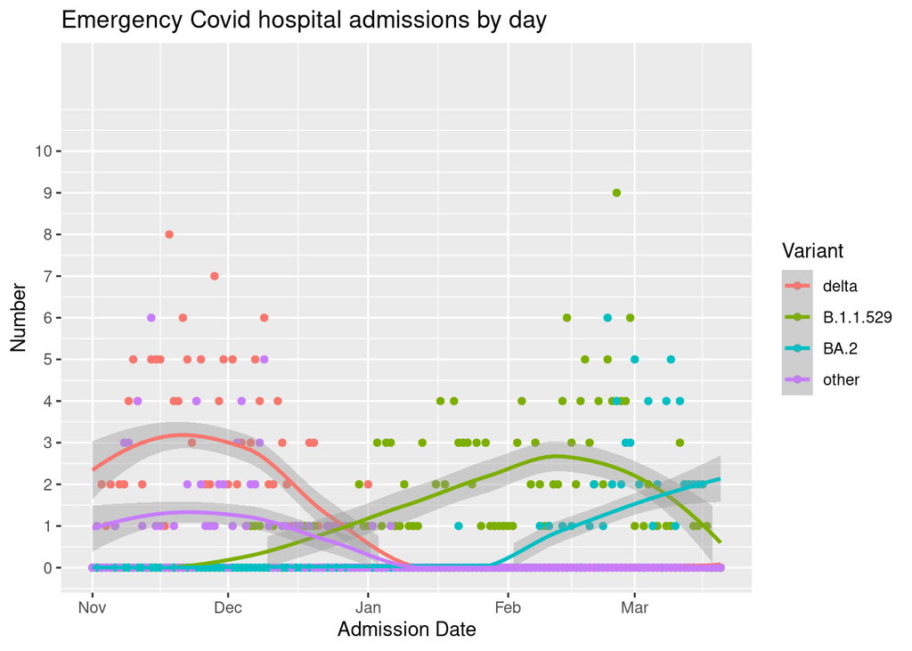

### Number of emergency covid hospital admission from community by vaccination status at specimen date

| vs | N | hosp_covid_emerg |
| --- | --- | --- |
| uv | 10812 | 99 |
| v1_0:27 | 185 | 1 |
| v1_28+ | 2447 | 17 |
| v2_0:27 | 189 | 1 |
| v2_28+ | 25594 | 163 |
| v3_0:27 | 5776 | 23 |
| v3_28+ | 36474 | 173 |

### Cumulative risk of emergency covid hospital admission from community by variant

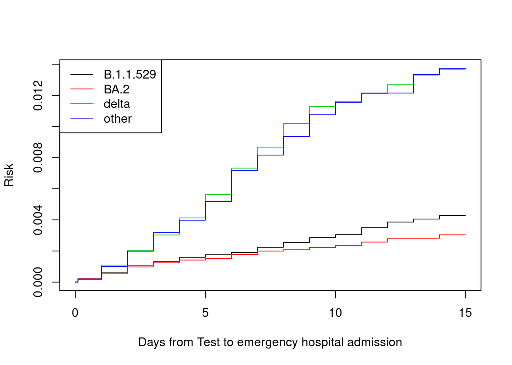

### Model selection statistics

|  | Df | AIC | LRT | Pr(>Chi) |
| --- | --- | --- | --- | --- |
|  | NA | 10162.62 | NA | NA |
| pspline(ageYear) | 4.040396 | 10237.98 | 83.4355570 | 3.483211e-17 |
| pspline(days) | 3.941703 | 10164.02 | 9.2830784 | 5.233074e-02 |
| Sex | 0.999375 | 10160.64 | 0.0170255 | 8.960292e-01 |
| simd2020_sc_quintile | 3.997715 | 10165.44 | 10.8132249 | 2.869782e-02 |
| variant | 2.872808 | 10168.06 | 11.1849382 | 9.554097e-03 |
| n_risk_gps | 4.993876 | 10301.37 | 148.7340317 | 2.455647e-30 |
| vs | 5.997371 | 10202.63 | 51.9998963 | 1.859094e-09 |

### Hazard Ratios for emergency covid hospital admission from community

| names | HR | LCL | UCL |
| --- | --- | --- | --- |
| SexM | 1.0116354 | 0.8439941 | 1.2125750 |
| simd2020_sc_quintile2 | 0.8207644 | 0.6348099 | 1.0611904 |
| simd2020_sc_quintile3 | 0.7126570 | 0.5395388 | 0.9413224 |
| simd2020_sc_quintile4 | 0.6757963 | 0.5094718 | 0.8964197 |
| simd2020_sc_quintile5 | 0.6995354 | 0.5265957 | 0.9292704 |
| variantBA.2 | 0.8538107 | 0.6069314 | 1.2011123 |
| variantdelta | 2.3449269 | 1.3909931 | 3.9530621 |
| variantother | 2.4973281 | 1.4706516 | 4.2407378 |
| n_risk_gps1 | 1.8759371 | 1.5059347 | 2.3368477 |
| n_risk_gps2 | 2.9486129 | 2.2182915 | 3.9193758 |
| n_risk_gps3 | 6.1208531 | 4.3133215 | 8.6858453 |
| n_risk_gps4 | 7.1710519 | 4.3380383 | 11.8542025 |
| n_risk_gps5+ | 10.8330227 | 6.0212834 | 19.4899282 |
| vsv1_0:27 | 0.5825763 | 0.0811445 | 4.1826007 |
| vsv1_28+ | 0.8695417 | 0.5185259 | 1.4581775 |
| vsv2_0:27 | 0.7070116 | 0.0984975 | 5.0749039 |
| vsv2_28+ | 0.4741421 | 0.3652886 | 0.6154333 |
| vsv3_0:27 | 0.2432616 | 0.1527428 | 0.3874237 |
| vsv3_28+ | 0.5337102 | 0.3973877 | 0.7167977 |

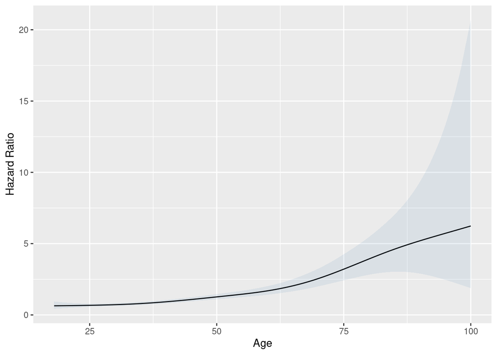

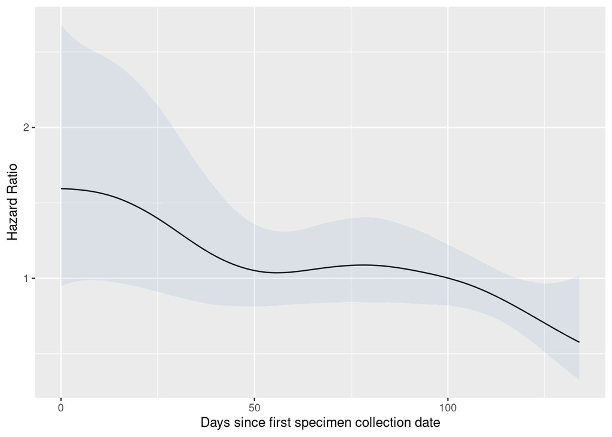

### Hazard Ratios for emergency covid hospital admission from NHS lab

| names | HR | LCL | UCL |
| --- | --- | --- | --- |
| SexM | 1.2657179 | 1.1455697 | 1.3984673 |
| simd2020_sc_quintile2 | 0.9211645 | 0.8059915 | 1.0527952 |
| simd2020_sc_quintile3 | 0.8641587 | 0.7470636 | 0.9996073 |
| simd2020_sc_quintile4 | 0.7027647 | 0.6001083 | 0.8229818 |
| simd2020_sc_quintile5 | 0.7321101 | 0.6160329 | 0.8700595 |
| variantBA.2 | 1.2002720 | 0.9731397 | 1.4804172 |
| variantdelta | 1.8444350 | 1.4133058 | 2.4070801 |
| variantother | 2.0254139 | 1.5721934 | 2.6092856 |
| n_risk_gps1 | 1.2968310 | 1.1250082 | 1.4948963 |
| n_risk_gps2 | 1.4286898 | 1.2222358 | 1.6700170 |
| n_risk_gps3 | 1.4802678 | 1.2402555 | 1.7667271 |
| n_risk_gps4 | 1.6028196 | 1.3086562 | 1.9631060 |
| n_risk_gps5+ | 1.7045070 | 1.3691521 | 2.1220025 |
| vsv1_0:27 | 1.0997010 | 0.4895712 | 2.4702071 |
| vsv1_28+ | 0.8293865 | 0.6318786 | 1.0886300 |
| vsv2_0:27 | 0.8089128 | 0.3339051 | 1.9596585 |
| vsv2_28+ | 0.7435886 | 0.6427064 | 0.8603057 |
| vsv3_0:27 | 0.4911938 | 0.3882543 | 0.6214260 |
| vsv3_28+ | 0.3613852 | 0.3125611 | 0.4178361 |

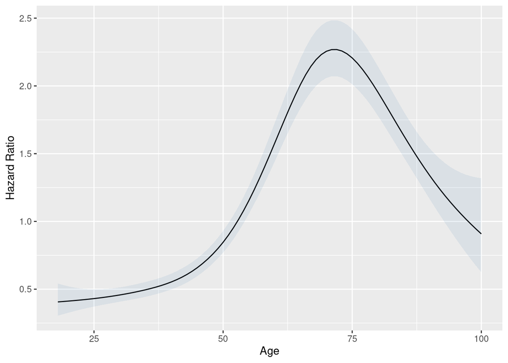

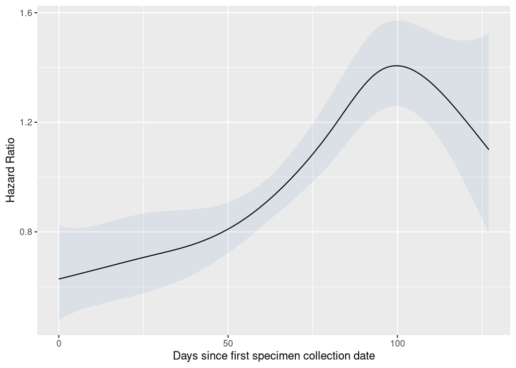

### Hazard Ratios for emergency admission from community, with interaction between variant and vaccine status

| names | HR | LCL | UCL |
| --- | --- | --- | --- |
| SexM | 1.0133590 | 0.8453335 | 1.2147826 |
| simd2020_sc_quintile2 | 0.8183728 | 0.6328934 | 1.0582098 |
| simd2020_sc_quintile3 | 0.7082759 | 0.5361811 | 0.9356070 |
| simd2020_sc_quintile4 | 0.6778020 | 0.5109494 | 0.8991409 |
| simd2020_sc_quintile5 | 0.7141625 | 0.5373802 | 0.9491008 |
| n_risk_gps1 | 1.8710251 | 1.5018946 | 2.3308791 |
| n_risk_gps2 | 2.9701671 | 2.2347025 | 3.9476809 |
| n_risk_gps3 | 6.0685765 | 4.2740106 | 8.6166425 |
| n_risk_gps4 | 7.2324076 | 4.3722696 | 11.9635165 |
| n_risk_gps5+ | 11.1981879 | 6.2247994 | 20.1451333 |
| variantBA.2 | 0.3323844 | 0.0975270 | 1.1328080 |
| variantdelta | 4.5732891 | 2.2482567 | 9.3027515 |
| variantother | 6.8853916 | 3.3031942 | 14.3523555 |
| variantB.1.1.529:vsv1_0:2 | NA | NA | NA |
| variantBA.2:vsv1_0:27 | NA | NA | NA |
| variantdelta:vsv1_0:27 | 1.3098761 | 0.1804087 | 9.5104910 |
| variantother:vsv1_0:27 | NA | NA | NA |
| variantB.1.1.529:vsv1_28+ | 2.4650775 | 1.1584848 | 5.2453058 |
| variantBA.2:vsv1_28+ | 4.7756399 | 0.9632281 | 23.6774004 |
| variantdelta:vsv1_28+ | 0.3220138 | 0.1000950 | 1.0359448 |
| variantother:vsv1_28+ | 0.1917037 | 0.0260223 | 1.4122610 |
| variantB.1.1.529:vsv2_0:2 | NA | NA | NA |
| variantBA.2:vsv2_0:27 | 37.4397069 | 3.8871110 | 360.6101451 |
| variantdelta:vsv2_0:27 | NA | NA | NA |
| variantother:vsv2_0:27 | NA | NA | NA |
| variantB.1.1.529:vsv2_28+ | 0.9505295 | 0.5502056 | 1.6421250 |
| variantBA.2:vsv2_28+ | 2.7603031 | 0.7592170 | 10.0356989 |
| variantdelta:vsv2_28+ | 0.3665875 | 0.2552635 | 0.5264612 |
| variantother:vsv2_28+ | 0.2328667 | 0.1384709 | 0.3916123 |
| variantB.1.1.529:vsv3_0:2 | 0.6131965 | 0.2762717 | 1.3610152 |
| variantBA.2:vsv3_0:27 | 0.0000000 | 0.0000000 | Inf |
| variantdelta:vsv3_0:27 | 0.1439955 | 0.0697181 | 0.2974078 |
| variantother:vsv3_0:27 | 0.1474286 | 0.0563833 | 0.3854895 |
| variantB.1.1.529:vsv3_28+ | 0.7320443 | 0.4531984 | 1.1824598 |
| variantBA.2:vsv3_28+ | 2.0403031 | 0.6345680 | 6.5601111 |
| variantdelta:vsv3_28+ | 0.6315181 | 0.3483600 | 1.1448360 |
| variantother:vsv3_28+ | 0.1756536 | 0.0604663 | 0.5102708 |

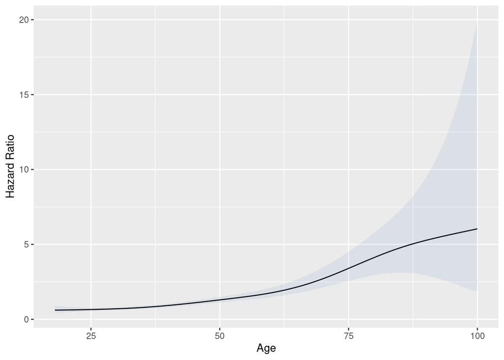

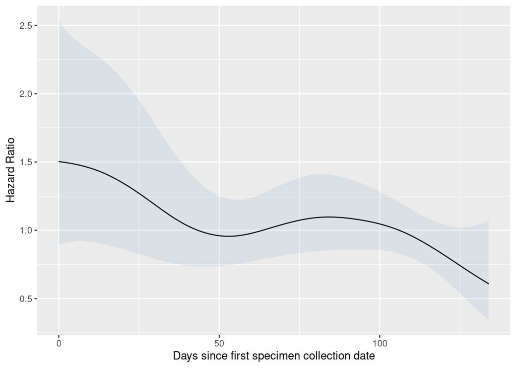

The NAs in the table above are due to the fact that these categories have zero events.

## Time to covid death

### Number of events and person years of follow up for covid deaths

| variant | pyears | n | event |
| --- | --- | --- | --- |
| B.1.1.529 | 3161.8234 | 48322 | 5 |
| BA.2 | 1302.2423 | 23325 | 1 |
| delta | 942.7680 | 13896 | 14 |
| other | 398.4422 | 5521 | 8 |

| variant_vs | pyears | n | event |
| --- | --- | --- | --- |
| B.1.1.529_uv | 397.889117 | 5985 | 0 |
| B.1.1.529_v1_0:27 | 7.512663 | 113 | 0 |
| B.1.1.529_v1_28+ | 91.134839 | 1388 | 0 |
| B.1.1.529_v2_0:27 | 7.808350 | 122 | 0 |
| B.1.1.529_v2_28+ | 827.164956 | 11779 | 0 |
| B.1.1.529_v3_0:27 | 297.377139 | 4116 | 1 |
| B.1.1.529_v3_28+ | 1532.936345 | 24819 | 4 |
| BA.2_uv | 160.629706 | 2861 | 0 |
| BA.2_v1_0:27 | 1.963039 | 29 | 0 |
| BA.2_v1_28+ | 35.811088 | 644 | 0 |
| BA.2_v2_0:27 | 1.875428 | 34 | 0 |
| BA.2_v2_28+ | 221.629021 | 3764 | 0 |
| BA.2_v3_0:27 | 28.298426 | 459 | 0 |
| BA.2_v3_28+ | 852.035592 | 15534 | 1 |
| delta_uv | 160.287474 | 2461 | 4 |
| delta_v1_0:27 | 3.334702 | 47 | 0 |
| delta_v1_28+ | 34.934976 | 530 | 0 |
| delta_v2_0:27 | 3.175907 | 46 | 0 |
| delta_v2_28+ | 624.377823 | 8909 | 5 |
| delta_v3_0:27 | 82.491444 | 1257 | 3 |
| delta_v3_28+ | 34.165640 | 646 | 2 |
| other_uv | 61.040383 | 881 | 3 |
| other_v1_0:27 | 1.429158 | 21 | 0 |
| other_v1_28+ | 13.815195 | 189 | 0 |
| other_v2_0:27 | 1.270363 | 17 | 0 |
| other_v2_28+ | 262.119097 | 3525 | 4 |
| other_v3_0:27 | 40.175222 | 569 | 0 |
| other_v3_28+ | 18.592745 | 319 | 1 |

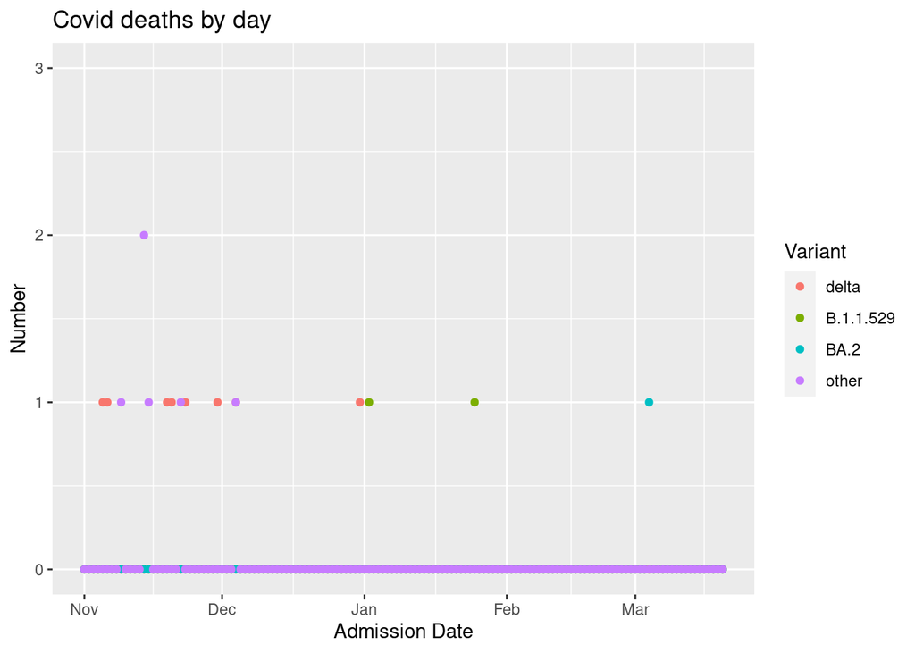

### Number of covid deaths by vaccination status at specimen date

| vs | N | Died |
| --- | --- | --- |
| uv | 10812 | 7 |
| v1_0:27 | 185 | 0 |
| v1_28+ | 2447 | 0 |
| v2_0:27 | 189 | 0 |
| v2_28+ | 25594 | 9 |
| v3_0:27 | 5776 | 4 |
| v3_28+ | 36474 | 8 |

### Cumulative risk of covid death by variant

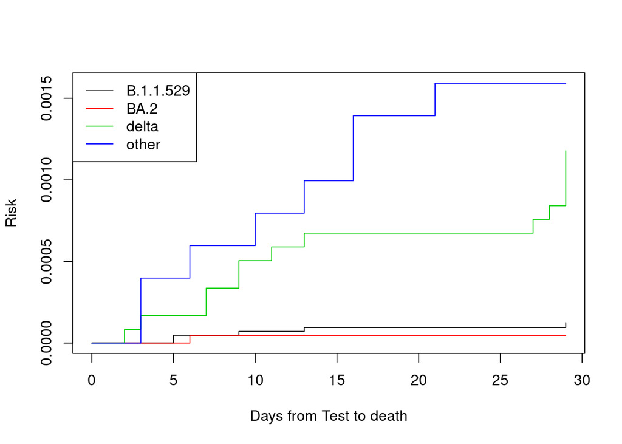

### Model selection statistics

|  | Df | AIC | LRT | Pr(>Chi) |
| --- | --- | --- | --- | --- |
|  | NA | 526.7439 | NA | NA |
| pspline(ageYear) | 3.9181657 | 569.2127 | 50.30517668 | 2.774265e-10 |
| pspline(days) | 3.8427688 | 526.8157 | 7.75734226 | 9.176253e-02 |
| Sex | 0.9990603 | 524.8279 | 0.08210892 | 7.741152e-01 |
| simd2020_sc_quintile | 3.9971020 | 522.8549 | 4.10519549 | 3.915361e-01 |
| variant | 2.8783143 | 524.5775 | 3.59022365 | 2.907109e-01 |
| n_risk_gps | 4.9962930 | 521.7281 | 4.97684900 | 4.182275e-01 |
| vs | 3.0017151 | 530.5630 | 9.82253069 | 2.016659e-02 |

### Hazard Ratios for covid death from community

| names | HR | LCL | UCL |
| --- | --- | --- | --- |
| SexM | 1.1108673 | 0.5249192 | 2.3508877 |
| simd2020_sc_quintile2 | 0.3389489 | 0.0858756 | 1.3378228 |
| simd2020_sc_quintile3 | 0.6043382 | 0.1898465 | 1.9237888 |
| simd2020_sc_quintile4 | 0.6121518 | 0.1924699 | 1.9469523 |
| simd2020_sc_quintile5 | 1.0513729 | 0.3759076 | 2.9405762 |
| variantBA.2 | 0.8940191 | 0.0586953 | 13.6172808 |
| variantdelta | 3.6011228 | 0.3347370 | 38.7411192 |
| variantother | 6.3725380 | 0.6060975 | 67.0011644 |
| n_risk_gps1 | 1.2254985 | 0.4473307 | 3.3573518 |
| n_risk_gps2 | 2.1474134 | 0.7093043 | 6.5012782 |
| n_risk_gps3 | 1.9650941 | 0.4798506 | 8.0474930 |
| n_risk_gps4 | 1.4273662 | 0.1657092 | 12.2948736 |
| n_risk_gps5+ | 7.6302196 | 1.3626212 | 42.7266596 |
| vsv1_0:27 | 0.0000000 | 0.0000000 | Inf |
| vsv1_28+ | 0.0000000 | 0.0000000 | Inf |
| vsv2_0:27 | 0.0000000 | 0.0000000 | Inf |
| vsv2_28+ | 0.2017310 | 0.0723203 | 0.5627101 |
| vsv3_0:27 | 0.1823797 | 0.0501316 | 0.6635005 |
| vsv3_28+ | 0.3413703 | 0.1016958 | 1.1459039 |

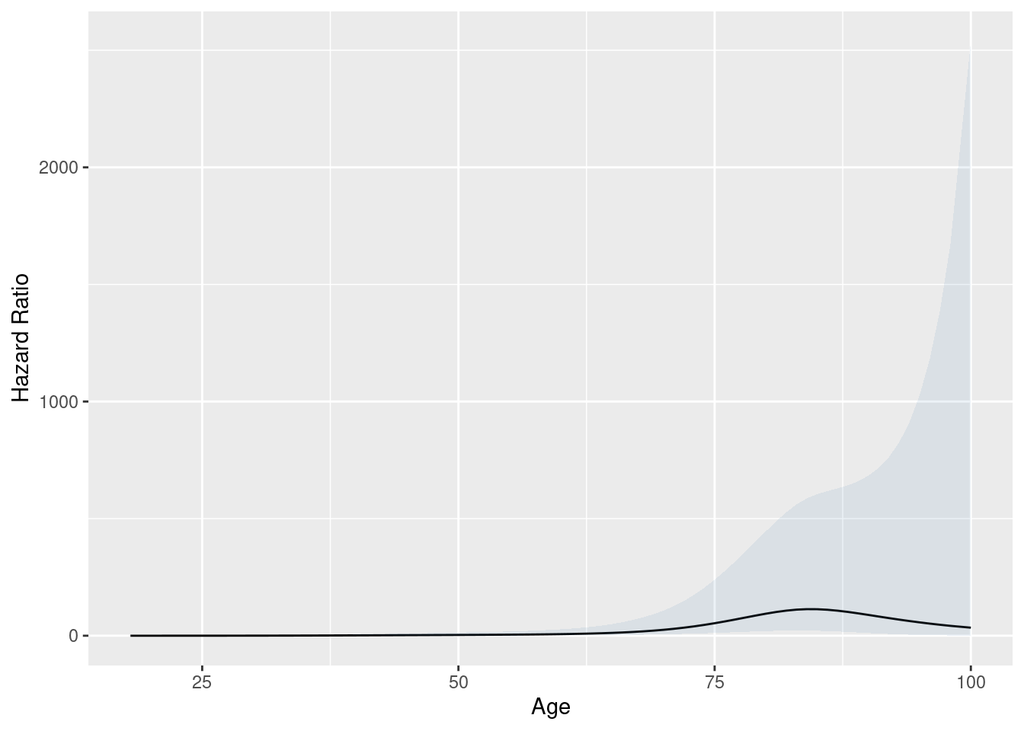

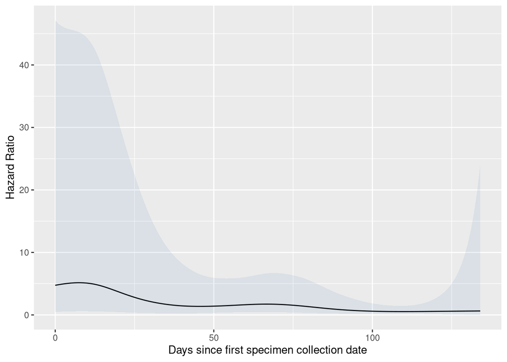

### Hazard Ratios for covid death from NHS lab

| names | HR | LCL | UCL |
| --- | --- | --- | --- |
| SexM | 1.6888860 | 1.3216185 | 2.1582144 |
| simd2020_sc_quintile2 | 0.8910231 | 0.6373482 | 1.2456648 |
| simd2020_sc_quintile3 | 1.0015659 | 0.7129701 | 1.4069793 |
| simd2020_sc_quintile4 | 0.7574414 | 0.5198430 | 1.1036360 |
| simd2020_sc_quintile5 | 0.6561171 | 0.4258557 | 1.0108816 |
| variantBA.2 | 0.1579445 | 0.0209070 | 1.1932084 |
| variantdelta | 2.2640321 | 1.2271158 | 4.1771455 |
| variantother | 1.6582371 | 0.8854475 | 3.1054922 |
| n_risk_gps1 | 1.9413418 | 1.2613205 | 2.9879859 |
| n_risk_gps2 | 2.0450745 | 1.3203488 | 3.1675944 |
| n_risk_gps3 | 1.7021210 | 1.0445023 | 2.7737765 |
| n_risk_gps4 | 3.0974438 | 1.9394230 | 4.9469138 |
| n_risk_gps5+ | 3.2353852 | 1.9669122 | 5.3219039 |
| vsv1_0:27 | 2.6600859 | 0.3627085 | 19.5089355 |
| vsv1_28+ | 1.5697796 | 0.9228544 | 2.6702024 |
| vsv2_0:27 | 0.0000000 | 0.0000000 | Inf |
| vsv2_28+ | 0.4831843 | 0.3411057 | 0.6844421 |
| vsv3_0:27 | 0.3169565 | 0.1906293 | 0.5269988 |
| vsv3_28+ | 0.2964812 | 0.2075796 | 0.4234573 |

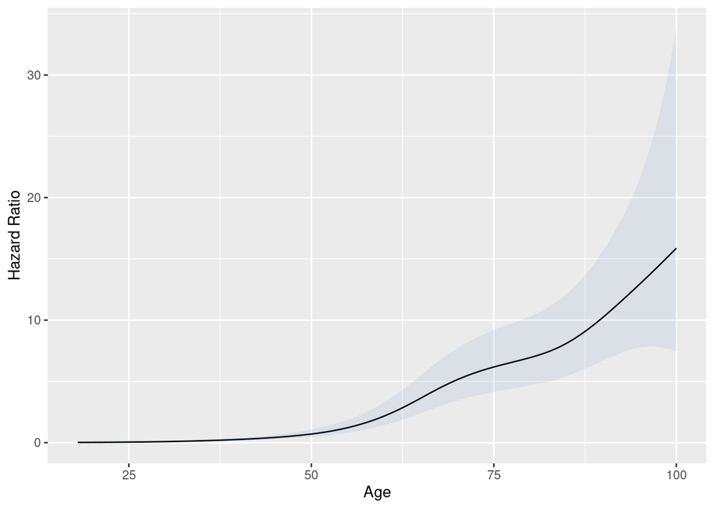

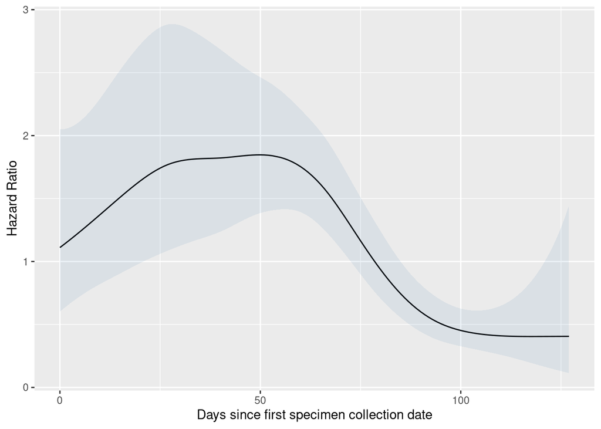

### Hazard Ratios for covid death, with interaction between variant and vaccine status

| names | HR | LCL | UCL |
| --- | --- | --- | --- |
| SexM | 1.115177e+00 | 0.5277913 | 2.3562701 |
| simd2020_sc_quintile2 | 3.223270e-01 | 0.0815566 | 1.2738972 |
| simd2020_sc_quintile3 | 6.018005e-01 | 0.1914412 | 1.8917756 |
| simd2020_sc_quintile4 | 5.970738e-01 | 0.1881470 | 1.8947795 |
| simd2020_sc_quintile5 | 1.060759e+00 | 0.3802639 | 2.9590230 |
| n_risk_gps1 | 1.261493e+00 | 0.4676715 | 3.4027413 |
| n_risk_gps2 | 2.362627e+00 | 0.7878806 | 7.0848356 |
| n_risk_gps3 | 1.974850e+00 | 0.4768125 | 8.1793876 |
| n_risk_gps4 | 1.475920e+00 | 0.1723144 | 12.6416640 |
| n_risk_gps5+ | 7.915139e+00 | 1.3230120 | 47.3536287 |
| variantBA.2 | 1.422130e+00 | 0.0000000 | Inf |
| variantdelta | 1.546159e+07 | 0.0000000 | Inf |
| variantother | 3.351447e+07 | 0.0000000 | Inf |
| variantB.1.1.529:vsv1_0:2 | 1.660667e+00 | 0.0000000 | Inf |
| variantBA.2:vsv1_0:27 | 2.634082e+00 | 0.0000000 | Inf |
| variantdelta:vsv1_0:27 | 0.000000e+00 | 0.0000000 | Inf |
| variantother:vsv1_0:27 | 0.000000e+00 | 0.0000000 | Inf |
| variantB.1.1.529:vsv1_28+ | 1.732561e+00 | 0.0000000 | Inf |
| variantBA.2:vsv1_28+ | 1.355390e+00 | 0.0000000 | Inf |
| variantdelta:vsv1_28+ | 0.000000e+00 | 0.0000000 | Inf |
| variantother:vsv1_28+ | 0.000000e+00 | 0.0000000 | Inf |
| variantB.1.1.529:vsv2_0:2 | 1.400017e+00 | 0.0000000 | Inf |
| variantBA.2:vsv2_0:27 | 2.487042e+00 | 0.0000000 | Inf |
| variantdelta:vsv2_0:27 | 0.000000e+00 | 0.0000000 | Inf |
| variantother:vsv2_0:27 | 0.000000e+00 | 0.0000000 | Inf |
| variantB.1.1.529:vsv2_28+ | 1.321617e+00 | 0.0000000 | Inf |
| variantBA.2:vsv2_28+ | 1.301744e+00 | 0.0000000 | Inf |
| variantdelta:vsv2_28+ | 1.539640e-01 | 0.0395498 | 0.5993688 |
| variantother:vsv2_28+ | 2.091508e-01 | 0.0445816 | 0.9812130 |
| variantB.1.1.529:vsv3_0:2 | 4.043916e+06 | 0.0000000 | Inf |
| variantBA.2:vsv3_0:27 | 1.334466e+00 | 0.0000000 | Inf |
| variantdelta:vsv3_0:27 | 1.751799e-01 | 0.0359962 | 0.8525345 |
| variantother:vsv3_0:27 | 0.000000e+00 | 0.0000000 | Inf |
| variantB.1.1.529:vsv3_28+ | 1.058914e+06 | 0.0000000 | Inf |
| variantBA.2:vsv3_28+ | 6.749875e+05 | 0.0000000 | Inf |
| variantdelta:vsv3_28+ | 3.274987e-01 | 0.0522689 | 2.0519928 |
| variantother:vsv3_28+ | 1.277055e-01 | 0.0119366 | 1.3662760 |

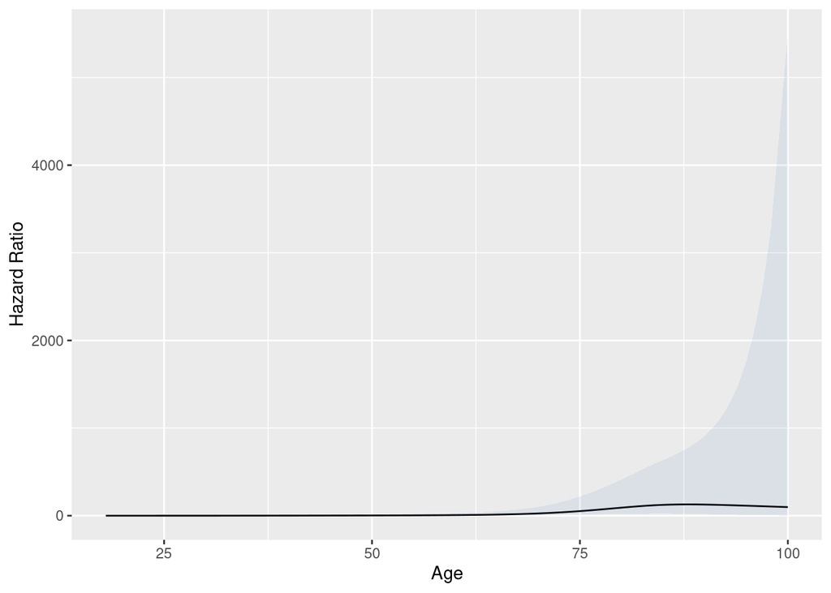

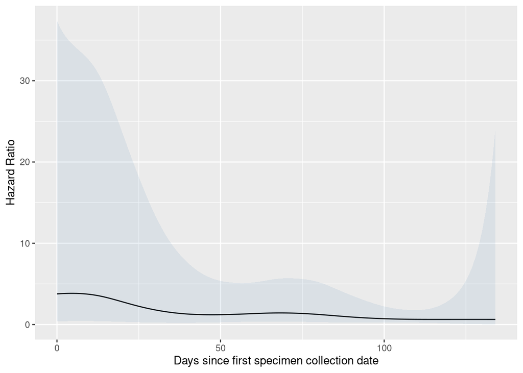

The Infs in the table above are due to the fact that these categories have zero events

```r
filter(df_seq, variant == 'other', vs =='v2_0:27', in_hosp_at_test == 0, lab == 'lh') %>%
  select(death_covid) %>%
  table()
```

. 0 16

## Time to emergency covid hospitalisation or covid death

### Number of events and person years of follow up for emergency covid hospitalisation or covid death

| variant | pyears | n | event |
| --- | --- | --- | --- |
| B.1.1.529 | 3147.7643 | 48322 | 183 |
| BA.2 | 1298.1670 | 23325 | 67 |
| delta | 931.6528 | 13896 | 168 |
| other | 393.6293 | 5521 | 71 |

| variant_vs | pyears | n | event |
| --- | --- | --- | --- |
| B.1.1.529_uv | 396.134702 | 5985 | 21 |
| B.1.1.529_v1_0:27 | 7.512663 | 113 | 0 |
| B.1.1.529_v1_28+ | 90.302532 | 1388 | 10 |
| B.1.1.529_v2_0:27 | 7.734428 | 122 | 0 |
| B.1.1.529_v2_28+ | 823.776044 | 11779 | 36 |
| B.1.1.529_v3_0:27 | 296.648871 | 4116 | 10 |
| B.1.1.529_v3_28+ | 1525.655031 | 24819 | 106 |
| BA.2_uv | 160.229980 | 2861 | 3 |
| BA.2_v1_0:27 | 1.963039 | 29 | 0 |
| BA.2_v1_28+ | 35.509925 | 644 | 3 |
| BA.2_v2_0:27 | 1.796304 | 34 | 1 |
| BA.2_v2_28+ | 220.906229 | 3764 | 10 |
| BA.2_v3_0:27 | 28.276523 | 459 | 0 |
| BA.2_v3_28+ | 849.485010 | 15534 | 50 |
| delta_uv | 156.966461 | 2461 | 50 |
| delta_v1_0:27 | 3.238878 | 47 | 1 |
| delta_v1_28+ | 34.658453 | 530 | 3 |
| delta_v2_0:27 | 3.175907 | 46 | 0 |
| delta_v2_28+ | 618.538535 | 8909 | 88 |
| delta_v3_0:27 | 81.875428 | 1257 | 10 |
| delta_v3_28+ | 33.199179 | 646 | 16 |
| other_uv | 59.164955 | 881 | 28 |
| other_v1_0:27 | 1.429158 | 21 | 0 |
| other_v1_28+ | 13.752225 | 189 | 1 |
| other_v2_0:27 | 1.270363 | 17 | 0 |
| other_v2_28+ | 259.890486 | 3525 | 33 |
| other_v3_0:27 | 39.830253 | 569 | 5 |
| other_v3_28+ | 18.291855 | 319 | 4 |

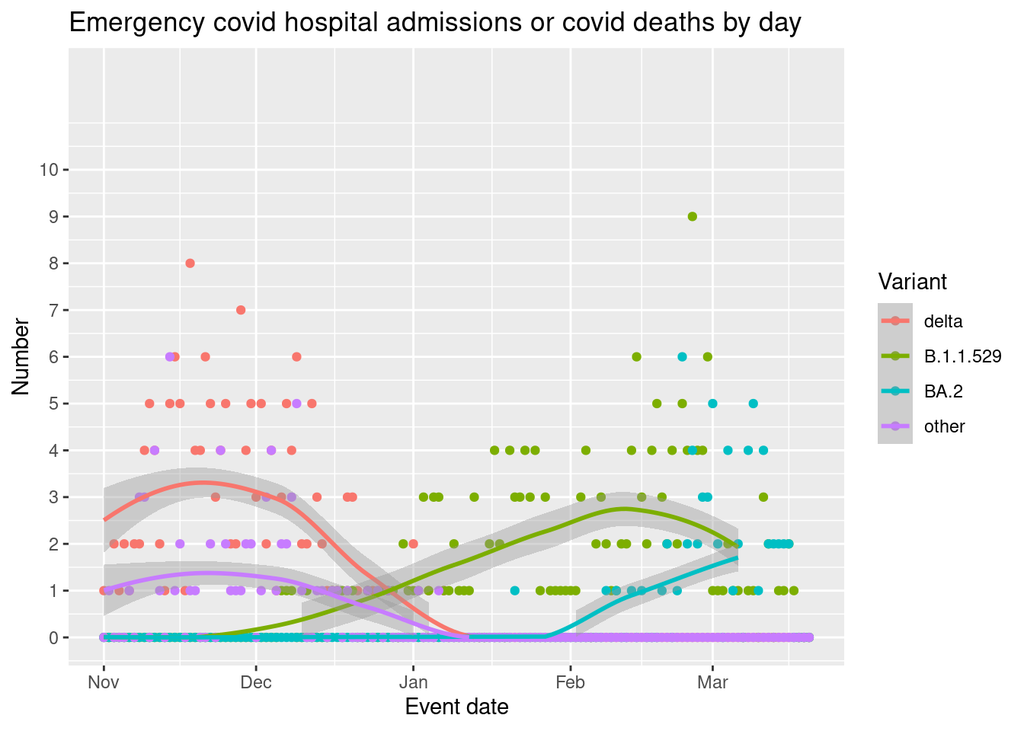

### Number of emergency covid hospital admissions or covid deaths by vaccination status at specimen date

| vs | N | Died |
| --- | --- | --- |
| uv | 10812 | 102 |
| v1_0:27 | 185 | 1 |
| v1_28+ | 2447 | 17 |
| v2_0:27 | 189 | 1 |
| v2_28+ | 25594 | 167 |
| v3_0:27 | 5776 | 25 |
| v3_28+ | 36474 | 176 |

### Number of covid deaths that were not covid hospitalisations by variant

| variant | n |
| --- | --- |
| B.1.1.529 | 4 |
| delta | 6 |
| other | 2 |

### Cumulative risk of emergency covid hospital admission or covid deaths by variant

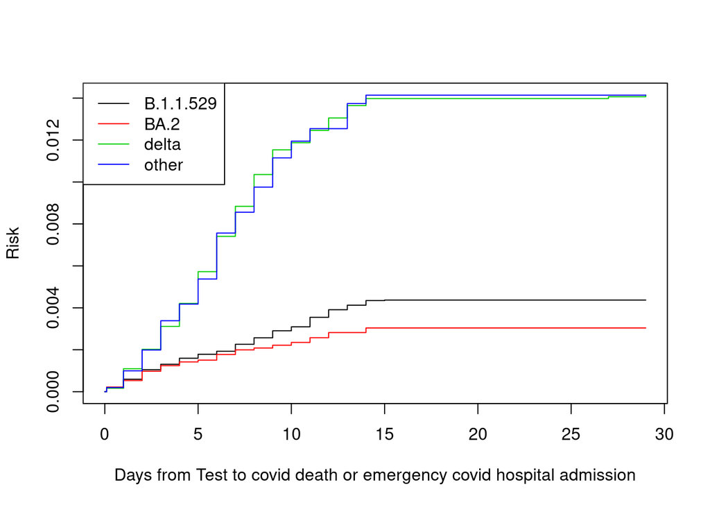

### Model selection statistics

|  | Df | AIC | LRT | Pr(>Chi) |
| --- | --- | --- | --- | --- |
|  | NA | 10405.55 | NA | NA |
| pspline(ageYear) | 4.0422524 | 10491.98 | 94.52060279 | 1.549996e-19 |
| pspline(days) | 3.9421050 | 10408.48 | 10.82136477 | 2.746485e-02 |
| Sex | 0.9993379 | 10403.60 | 0.05485203 | 8.146022e-01 |
| simd2020_sc_quintile | 3.9977126 | 10408.40 | 10.84673014 | 2.829473e-02 |
| n_risk_gps | 4.9938647 | 10540.33 | 144.77255889 | 1.710279e-29 |
| variant | 2.8717382 | 10411.20 | 11.40083224 | 8.629258e-03 |
| vs | 5.9972961 | 10446.48 | 52.93076748 | 1.207652e-09 |

### Hazard Ratios for emergency covid hospitalisation or covid death from community

| names | HR | LCL | UCL |
| --- | --- | --- | --- |
| SexM | 1.0211977 | 0.8539578 | 1.2211900 |
| simd2020_sc_quintile2 | 0.8074731 | 0.6257399 | 1.0419869 |
| simd2020_sc_quintile3 | 0.7092026 | 0.5386875 | 0.9336923 |
| simd2020_sc_quintile4 | 0.6726344 | 0.5088323 | 0.8891673 |
| simd2020_sc_quintile5 | 0.7139911 | 0.5404831 | 0.9431993 |
| n_risk_gps1 | 1.8641786 | 1.5008656 | 2.3154383 |
| n_risk_gps2 | 2.9027665 | 2.1918181 | 3.8443212 |
| n_risk_gps3 | 5.8941763 | 4.1692038 | 8.3328414 |
| n_risk_gps4 | 6.6849521 | 4.0490630 | 11.0367717 |
| n_risk_gps5+ | 10.0179157 | 5.5763876 | 17.9970697 |
| variantBA.2 | 0.8429486 | 0.5998728 | 1.1845219 |
| variantdelta | 2.3262084 | 1.3869593 | 3.9015171 |
| variantother | 2.4722353 | 1.4633858 | 4.1765797 |
| vsv1_0:27 | 0.5682311 | 0.0791719 | 4.0782994 |
| vsv1_28+ | 0.8492063 | 0.5069711 | 1.4224704 |
| vsv2_0:27 | 0.6885572 | 0.0959560 | 4.9409179 |
| vsv2_28+ | 0.4679924 | 0.3618176 | 0.6053241 |
| vsv3_0:27 | 0.2518754 | 0.1607169 | 0.3947388 |
| vsv3_28+ | 0.5232878 | 0.3909452 | 0.7004310 |

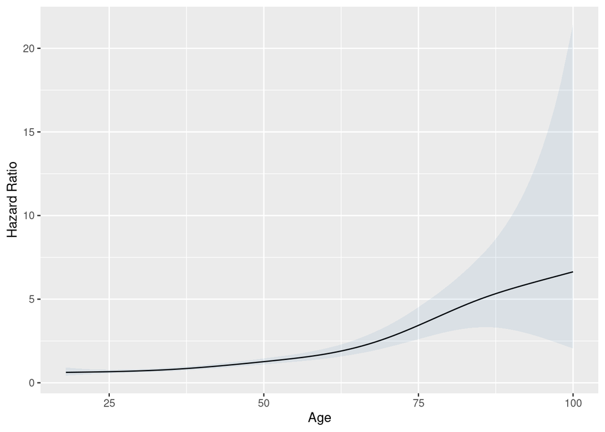

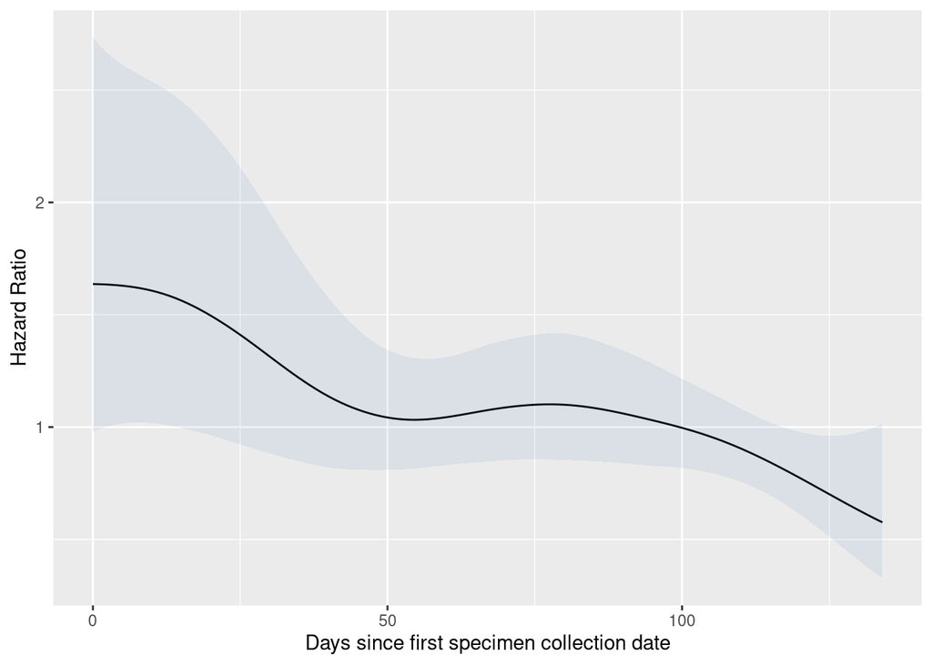

### Hazard Ratios for emergency covid hospitalisation or covid death from NHS lab

| names | HR | LCL | UCL |
| --- | --- | --- | --- |
| SexM | 1.3017080 | 1.1825004 | 1.4329330 |
| simd2020_sc_quintile2 | 0.9176687 | 0.8067771 | 1.0438024 |
| simd2020_sc_quintile3 | 0.8532533 | 0.7414879 | 0.9818652 |
| simd2020_sc_quintile4 | 0.7093304 | 0.6098592 | 0.8250259 |
| simd2020_sc_quintile5 | 0.7321684 | 0.6207874 | 0.8635332 |
| n_risk_gps1 | 1.3397605 | 1.1667172 | 1.5384689 |
| n_risk_gps2 | 1.4899146 | 1.2811533 | 1.7326932 |
| n_risk_gps3 | 1.4912742 | 1.2559843 | 1.7706421 |
| n_risk_gps4 | 1.7054959 | 1.4068081 | 2.0676000 |
| n_risk_gps5+ | 1.8006392 | 1.4624781 | 2.2169914 |
| variantBA.2 | 1.1625032 | 0.9434170 | 1.4324668 |
| variantdelta | 1.8900517 | 1.4650388 | 2.4383623 |
| variantother | 1.9595699 | 1.5329690 | 2.5048870 |
| vsv1_0:27 | 1.2148825 | 0.5738315 | 2.5720784 |
| vsv1_28+ | 0.8430730 | 0.6499800 | 1.0935291 |
| vsv2_0:27 | 0.7428500 | 0.3067572 | 1.7989019 |
| vsv2_28+ | 0.7150999 | 0.6212546 | 0.8231211 |
| vsv3_0:27 | 0.4617449 | 0.3680737 | 0.5792544 |
| vsv3_28+ | 0.3554593 | 0.3090877 | 0.4087879 |

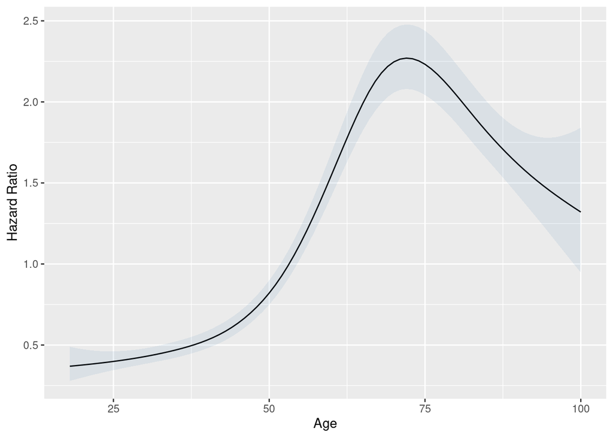

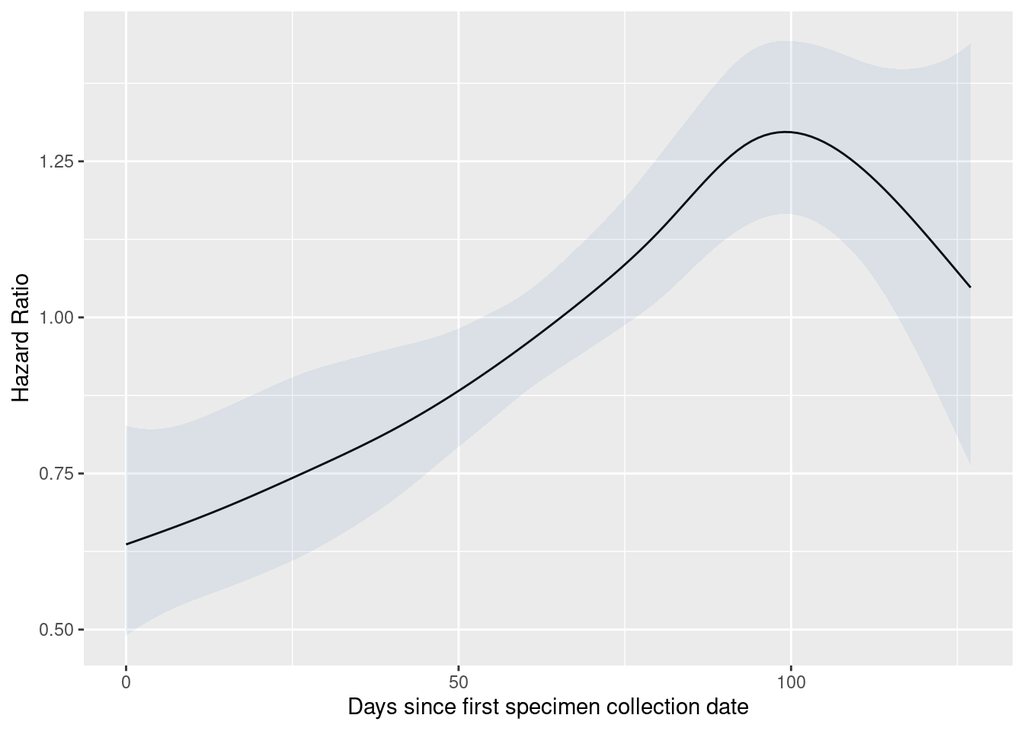

#### Hazard Ratios for emergency covid hospitalisation or covid death from community testing, with interaction between variant and vaccine status

| names | HR | LCL | UCL |
| --- | --- | --- | --- |
| SexM | 1.0227148 | 0.8551358 | 1.2231339 |
| simd2020_sc_quintile2 | 0.8048476 | 0.6236404 | 1.0387071 |
| simd2020_sc_quintile3 | 0.7056982 | 0.5359881 | 0.9291438 |
| simd2020_sc_quintile4 | 0.6749014 | 0.5105093 | 0.8922304 |
| simd2020_sc_quintile5 | 0.7284328 | 0.5511890 | 0.9626721 |
| n_risk_gps1 | 1.8609672 | 1.4981803 | 2.3116035 |
| n_risk_gps2 | 2.9288933 | 2.2117265 | 3.8786062 |
| n_risk_gps3 | 5.8509763 | 4.1362241 | 8.2766122 |
| n_risk_gps4 | 6.7476807 | 4.0844652 | 11.1474070 |
| n_risk_gps5+ | 10.3484056 | 5.7601018 | 18.5915983 |
| variantBA.2 | 0.3343254 | 0.0981128 | 1.1392343 |
| variantdelta | 4.8333590 | 2.3901621 | 9.7739646 |
| variantother | 6.8528203 | 3.2939162 | 14.2569341 |
| variantB.1.1.529:vsv1_0:2 | NA | NA | NA |
| variantBA.2:vsv1_0:27 | NA | NA | NA |
| variantdelta:vsv1_0:27 | 1.2376301 | 0.1706755 | 8.9745071 |
| variantother:vsv1_0:27 | NA | NA | NA |
| variantB.1.1.529:vsv1_28+ | 2.4855758 | 1.1681240 | 5.2888967 |
| variantBA.2:vsv1_28+ | 4.8177535 | 0.9717242 | 23.8861484 |
| variantdelta:vsv1_28+ | 0.3048110 | 0.0949477 | 0.9785358 |
| variantother:vsv1_28+ | 0.1924102 | 0.0261183 | 1.4174597 |
| variantB.1.1.529:vsv2_0:2 | NA | NA | NA |
| variantBA.2:vsv2_0:27 | 37.9641727 | 3.9416224 | 365.6561352 |
| variantdelta:vsv2_0:27 | NA | NA | NA |
| variantother:vsv2_0:27 | NA | NA | NA |
| variantB.1.1.529:vsv2_28+ | 0.9571237 | 0.5540802 | 1.6533451 |
| variantBA.2:vsv2_28+ | 2.7783633 | 0.7641743 | 10.1014946 |
| variantdelta:vsv2_28+ | 0.3498761 | 0.2456938 | 0.4982352 |
| variantother:vsv2_28+ | 0.2471269 | 0.1480307 | 0.4125609 |
| variantB.1.1.529:vsv3_0:2 | 0.6815763 | 0.3156672 | 1.4716327 |
| variantBA.2:vsv3_0:27 | 0.0000000 | 0.0000000 | Inf |
| variantdelta:vsv3_0:27 | 0.1466760 | 0.0734629 | 0.2928534 |
| variantother:vsv3_0:27 | 0.1447869 | 0.0553824 | 0.3785180 |
| variantB.1.1.529:vsv3_28+ | 0.7418519 | 0.4598840 | 1.1967023 |
| variantBA.2:vsv3_28+ | 2.0164127 | 0.6271804 | 6.4828555 |
| variantdelta:vsv3_28+ | 0.5816693 | 0.3223530 | 1.0495922 |
| variantother:vsv3_28+ | 0.1713260 | 0.0589996 | 0.4975046 |

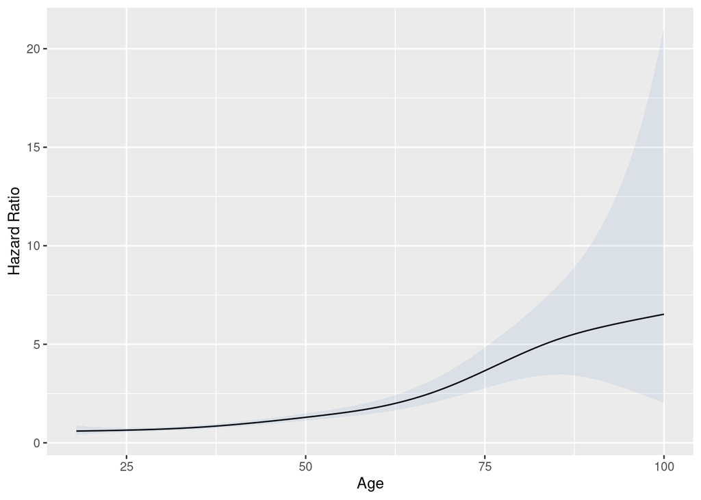

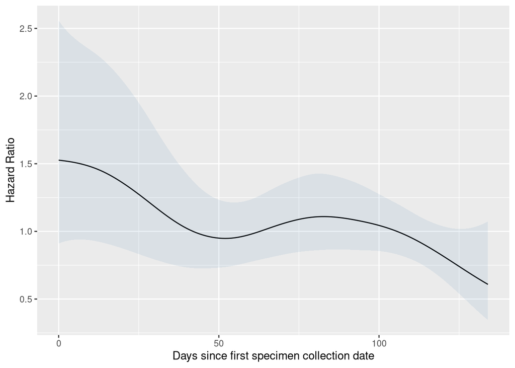

|  | Df | AIC | LRT | Pr(>Chi) |
| --- | --- | --- | --- | --- |
|  | NA | 10354.06 | NA | NA |
| variant:vs | -0.9420726 | 10405.55 | 49.6002 | NA |

The NA in the table above is due to the fact that the category has zero events

#### Hazard Ratios for emergency covid hospitalisation or covid death from community testing, with interaction between variant and vaccine status by vaccine type

| names | HR | LCL | UCL |
| --- | --- | --- | --- |
| SexM | 1.020704e+00 | 0.8533135 | 1.220932 |
| simd2020_sc_quintile2 | 8.157496e-01 | 0.6316112 | 1.053571 |
| simd2020_sc_quintile3 | 7.121409e-01 | 0.5408575 | 0.937668 |
| simd2020_sc_quintile4 | 6.841701e-01 | 0.5173640 | 0.904757 |
| simd2020_sc_quintile5 | 7.573270e-01 | 0.5730398 | 1.000880 |
| n_risk_gps1 | 1.836581e+00 | 1.4810301 | 2.277489 |
| n_risk_gps2 | 2.852073e+00 | 2.1573173 | 3.770572 |
| n_risk_gps3 | 5.925235e+00 | 4.1709706 | 8.417322 |
| n_risk_gps4 | 6.846325e+00 | 4.0755235 | 11.500894 |
| n_risk_gps5. | 1.058813e+01 | 5.6513080 | 19.837606 |
| variantBA.2 | 1.087003e+00 | 0.0000000 | Inf |
| variantdelta | 3.481905e-01 | 0.0000000 | Inf |
| variantother | 6.038636e-01 | 0.0000000 | Inf |
| variantB.1.1.529.vs_typeA | 5.471051e+08 | 0.0000000 | Inf |
| variantBA.2.vs_typeAZ_v1_ | 4.918303e-01 | 0.0000000 | Inf |
| variantdelta.vs_typeAZ_v1 | 3.263920e+08 | 0.0000000 | Inf |
| variantother.vs_typeAZ_v1 | 6.920815e-01 | 0.0000000 | Inf |
| variantB.1.1.529.vs_typeA.1 | 6.492207e-01 | 0.0000000 | Inf |
| variantBA.2.vs_typeAZ_v2_ | 6.341640e-01 | 0.0000000 | Inf |
| variantdelta.vs_typeAZ_v2 | 1.516470e+00 | 0.0000000 | Inf |
| variantother.vs_typeAZ_v2 | 5.378091e-01 | 0.0000000 | Inf |
| variantB.1.1.529.vs_typeA.2 | 1.186156e+08 | 0.0000000 | Inf |
| variantBA.2.vs_typeAZ_v2_.1 | 1.295602e+08 | 0.0000000 | Inf |
| variantdelta.vs_typeAZ_v2.1 | 5.747208e+08 | 0.0000000 | Inf |
| variantother.vs_typeAZ_v2.1 | 3.323044e+08 | 0.0000000 | Inf |
| variantB.1.1.529.vs_typeA.3 | 6.103814e-01 | 0.0000000 | Inf |
| variantBA.2.vs_typeAZ_v3_ | 5.459948e-01 | 0.0000000 | Inf |
| variantdelta.vs_typeAZ_v3 | 6.855235e-01 | 0.0000000 | Inf |
| variantother.vs_typeAZ_v3 | 1.645939e-01 | 0.0000000 | Inf |
| variantB.1.1.529.vs_typeA.4 | 2.744778e+08 | 0.0000000 | Inf |

[output cut: 55 more lines]

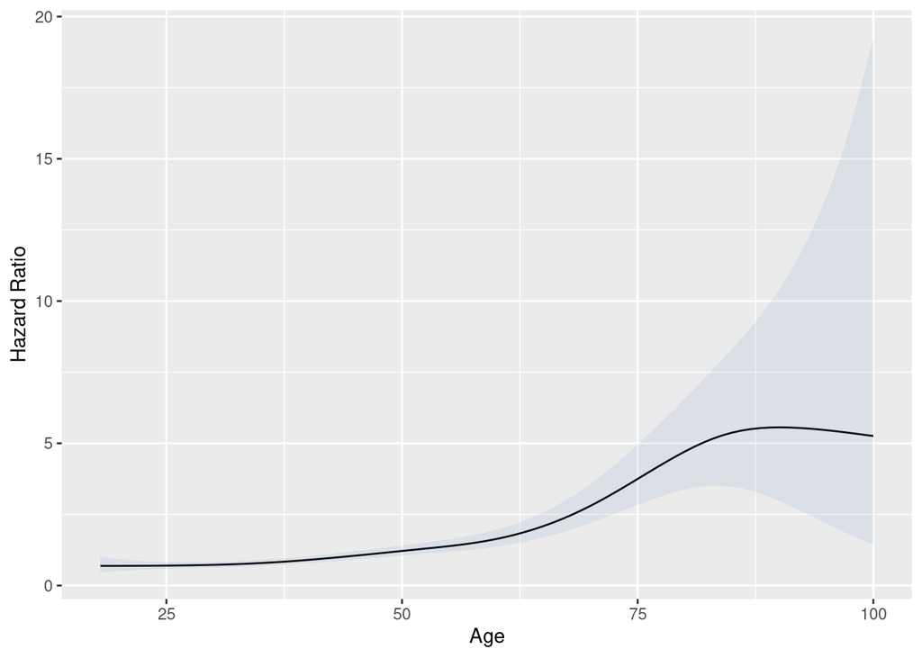

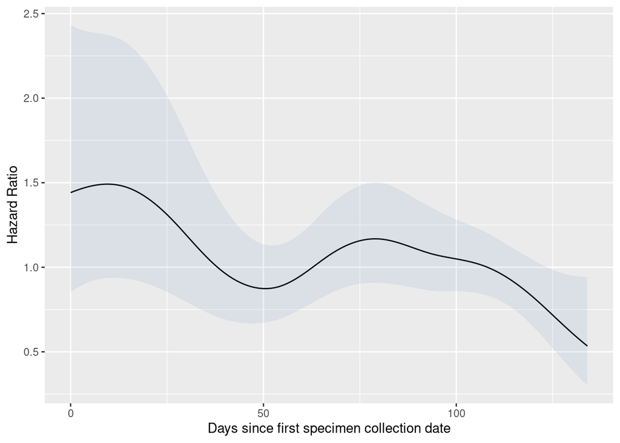

| names | HR | LCL | UCL |
| --- | --- | --- | --- |
| SexM | 1.039292e+00 | 0.8673114 | 1.2453743 |
| simd2020_sc_quintile2 | 8.394353e-01 | 0.6473704 | 1.0884829 |
| simd2020_sc_quintile3 | 7.418154e-01 | 0.5619845 | 0.9791908 |
| simd2020_sc_quintile4 | 6.956278e-01 | 0.5235581 | 0.9242489 |
| simd2020_sc_quintile5 | 7.974410e-01 | 0.6018531 | 1.0565903 |
| n_risk_gps1 | 1.774848e+00 | 1.4267782 | 2.2078312 |
| n_risk_gps2 | 2.798914e+00 | 2.1127712 | 3.7078887 |
| n_risk_gps3 | 5.882569e+00 | 4.1423175 | 8.3539261 |
| n_risk_gps4 | 6.735249e+00 | 4.0124403 | 11.3057339 |
| n_risk_gps5+ | 1.039156e+01 | 5.5566895 | 19.4332348 |
| varBA.2 | 1.040187e+00 | 0.0000000 | Inf |
| vardelta | 3.714077e-01 | 0.0000000 | Inf |
| varother | 6.210064e-01 | 0.0000000 | Inf |
| varB.1.1.529:vs_tAZ_v1_28 | 5.257097e+08 | 0.0000000 | Inf |
| varBA.2:vs_tAZ_v1_28+ | 5.062841e-01 | 0.0000000 | Inf |
| vardelta:vs_tAZ_v1_28+ | 3.131785e+08 | 0.0000000 | Inf |
| varother:vs_tAZ_v1_28+ | 7.079216e-01 | 0.0000000 | Inf |
| varB.1.1.529:vs_tAZ_v2_0: | 6.345310e-01 | 0.0000000 | Inf |
| varBA.2:vs_tAZ_v2_0:27 | 6.468610e-01 | 0.0000000 | Inf |
| vardelta:vs_tAZ_v2_0:27 | 1.479053e+00 | 0.0000000 | Inf |
| varother:vs_tAZ_v2_0:27 | 5.585253e-01 | 0.0000000 | Inf |
| varB.1.1.529:vs_tAZ_v2_28 | 1.143569e+08 | 0.0000000 | Inf |
| varBA.2:vs_tAZ_v2_28+ | 1.290260e+08 | 0.0000000 | Inf |
| vardelta:vs_tAZ_v2_28+ | 5.496258e+08 | 0.0000000 | Inf |
| varother:vs_tAZ_v2_28+ | 3.288600e+08 | 0.0000000 | Inf |
| varB.1.1.529:vs_tAZ_v3_0: | 6.113394e-01 | 0.0000000 | Inf |
| varBA.2:vs_tAZ_v3_0:27 | 5.707279e-01 | 0.0000000 | Inf |
| vardelta:vs_tAZ_v3_0:27 | 6.591857e-01 | 0.0000000 | Inf |
| varother:vs_tAZ_v3_0:27 | 1.705520e-01 | 0.0000000 | Inf |
| varB.1.1.529:vs_tAZ_v3_28 | 2.591542e+08 | 0.0000000 | Inf |
| varBA.2:vs_tAZ_v3_28+ | 5.818097e+08 | 0.0000000 | Inf |
| vardelta:vs_tAZ_v3_28+ | 5.949376e+09 | 0.0000000 | Inf |
| varother:vs_tAZ_v3_28+ | 4.072605e-01 | 0.0000000 | Inf |
| varB.1.1.529:vs_tMo_v3_0: | 6.691680e+07 | 0.0000000 | Inf |
| varBA.2:vs_tMo_v3_0:27 | 7.037061e-01 | 0.0000000 | Inf |
| vardelta:vs_tMo_v3_0:27 | 9.024844e+07 | 0.0000000 | Inf |
| varother:vs_tMo_v3_0:27 | 1.223193e+08 | 0.0000000 | Inf |
| varB.1.1.529:vs_tMo_v3_28 | 4.587349e+07 | 0.0000000 | Inf |
| varBA.2:vs_tMo_v3_28+ | 4.321871e+07 | 0.0000000 | Inf |
| vardelta:vs_tMo_v3_28+ | 3.170678e+08 | 0.0000000 | Inf |
| varother:vs_tMo_v3_28+ | 3.513292e-01 | 0.0000000 | Inf |
| varB.1.1.529:vs_tPB_v1_0: | 7.148144e-01 | 0.0000000 | Inf |
| varBA.2:vs_tPB_v1_0:27 | 7.618811e-01 | 0.0000000 | Inf |
| vardelta:vs_tPB_v1_0:27 | 1.910639e+09 | 0.0000000 | Inf |
| varother:vs_tPB_v1_0:27 | 1.022080e+00 | 0.0000000 | Inf |
| varB.1.1.529:vs_tPB_v1_28 | 1.149812e+08 | 0.0000000 | Inf |
| varBA.2:vs_tPB_v1_28+ | 2.530858e+08 | 0.0000000 | Inf |
| vardelta:vs_tPB_v1_28+ | 5.071428e+08 | 0.0000000 | Inf |
| varother:vs_tPB_v1_28+ | 3.988429e+08 | 0.0000000 | Inf |
| varB.1.1.529:vs_tPB_v2_0: | 7.907080e-01 | 0.0000000 | Inf |
| varBA.2:vs_tPB_v2_0:27 | 7.792884e-01 | 0.0000000 | Inf |
| vardelta:vs_tPB_v2_0:27 | 2.261737e+00 | 0.0000000 | Inf |
| varother:vs_tPB_v2_0:27 | 1.227109e+00 | 0.0000000 | Inf |
| varB.1.1.529:vs_tPB_v2_28 | 6.809999e+07 | 0.0000000 | Inf |
| varBA.2:vs_tPB_v2_28+ | 4.580655e+07 | 0.0000000 | Inf |
| vardelta:vs_tPB_v2_28+ | 2.842029e+08 | 0.0000000 | Inf |
| varother:vs_tPB_v2_28+ | 1.743730e+08 | 0.0000000 | Inf |
| varB.1.1.529:vs_tPB_v3_0: | 6.983258e+07 | 0.0000000 | Inf |
| varBA.2:vs_tPB_v3_0:27 | 7.403887e-01 | 0.0000000 | Inf |
| vardelta:vs_tPB_v3_0:27 | 2.230858e+08 | 0.0000000 | Inf |
| varother:vs_tPB_v3_0:27 | 1.852696e+08 | 0.0000000 | Inf |
| varB.1.1.529:vs_tPB_v3_28 | 7.519532e+07 | 0.0000000 | Inf |
| varBA.2:vs_tPB_v3_28+ | 6.563010e+07 | 0.0000000 | Inf |
| vardelta:vs_tPB_v3_28+ | 8.122090e+08 | 0.0000000 | Inf |
| varother:vs_tPB_v3_28+ | 2.172378e+08 | 0.0000000 | Inf |
| varB.1.1.529:vs_tuv | 8.673595e+07 | 0.0000000 | Inf |
| varBA.2:vs_tuv | 2.907898e+07 | 0.0000000 | Inf |
| vardelta:vs_tuv | 1.304757e+09 | 0.0000000 | Inf |
| varother:vs_tuv | 1.021236e+09 | 0.0000000 | Inf |

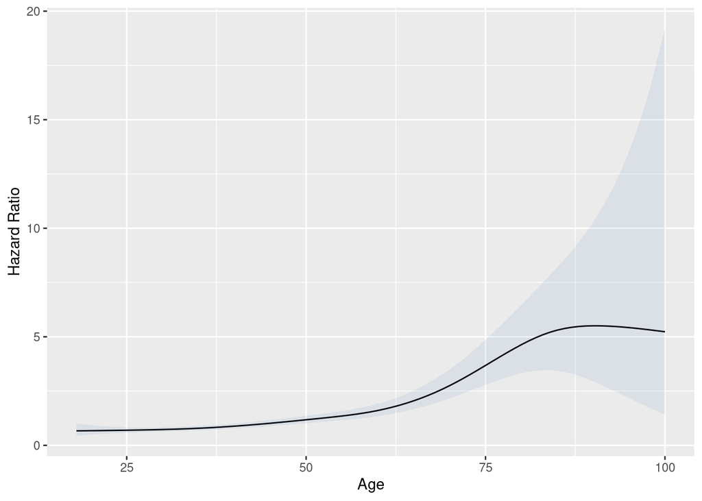

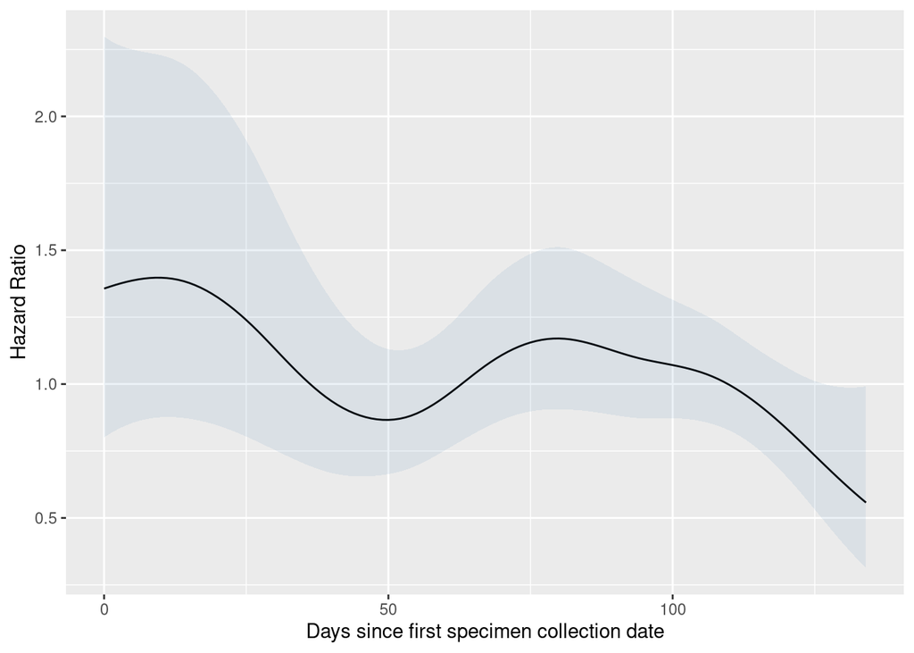